# Kaggle: Predicting Survival on the Titanic

Anthony Pan

2020-05-07

## Introduction

This is my first Kaggle exercise! The goal is to predict which passengers survived the Titanic shipwreck, given a set of attributes about the passengers. This file takes < 60 seconds to knit, and as of May 2020, the result places within the top 12% of submissions.

Kaggle allows us to skip the processes of data gathering, architecture, governance, and extraction, so we can move straight to importing and cleaning the data.

### Import Data

The training data has 891 observations, and the test data has 418 observations.

For each passenger, there are 10 predictors along with their passenger ID:

- Pclass (ticket class, proxy for socio-economic status)
- Name (passenger name: Last, First)
- Sex (male/female)
- Age (years)
- SibSp (# siblings and spouses aboard the Titanic)
- Parch (# parents and children abard the Titanic)
- Ticket (ticket number)
- Fare (passenger fare)
- Cabin (cabin number)
- Embarked (port of embarkation: Cherbourg, Queenstown, or Southampton)

```r
train <- read_csv("train.csv")
test <- read_csv("test.csv")
head(train)
```

```
## # A tibble: 6 x 12
##   PassengerId Survived Pclass Name  Sex     Age SibSp Parch Ticket  Fare Cabin
##         <dbl>    <dbl>  <dbl> <chr> <chr> <dbl> <dbl> <dbl> <chr>  <dbl> <chr>
## 1           1        0      3 Brau… male     22     1     0 A/5 2…  7.25 <NA>
## 2           2        1      1 Cumi… fema…    38     1     0 PC 17… 71.3  C85
## 3           3        1      3 Heik… fema…    26     0     0 STON/…  7.92 <NA>
## 4           4        1      1 Futr… fema…    35     1     0 113803 53.1  C123
## 5           5        0      3 Alle… male     35     0     0 373450  8.05 <NA>
## 6           6        0      3 Mora… male     NA     0     0 330877  8.46 <NA>
## # … with 1 more variable: Embarked <chr>
```

## Data Wrangling

### Exploration: Sex

Sex had a very disproportionate effect on survival on the Titanic. We can see that approximately 75% of females survived, compared to less than 20% of males.

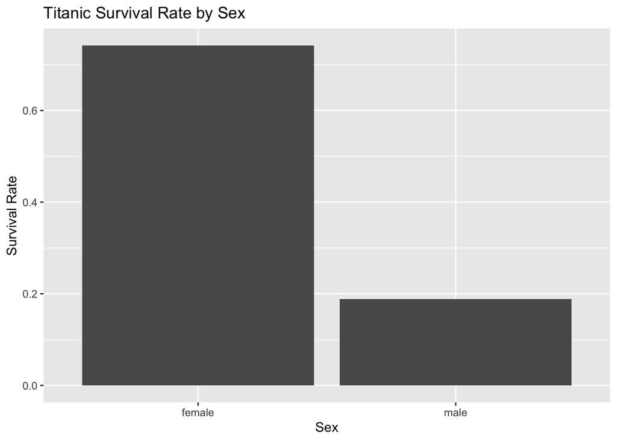

```r
train %>%
  group_by(Sex) %>%
  summarize(Survived = sum(Survived),
            Total = n(),
            Proportion = Survived/Total) %>%
  ggplot() +
    geom_col(mapping = aes(x = Sex, y = Proportion)) +
    labs(title = "Titanic Survival Rate by Sex", y = "Survival Rate")
```

### Exploration: Ticket Class

Ticket class seems to greatly affect survival rate as well. More than 60% of 1st class passengers survived, while less than 25% of 3rd class passengers did.

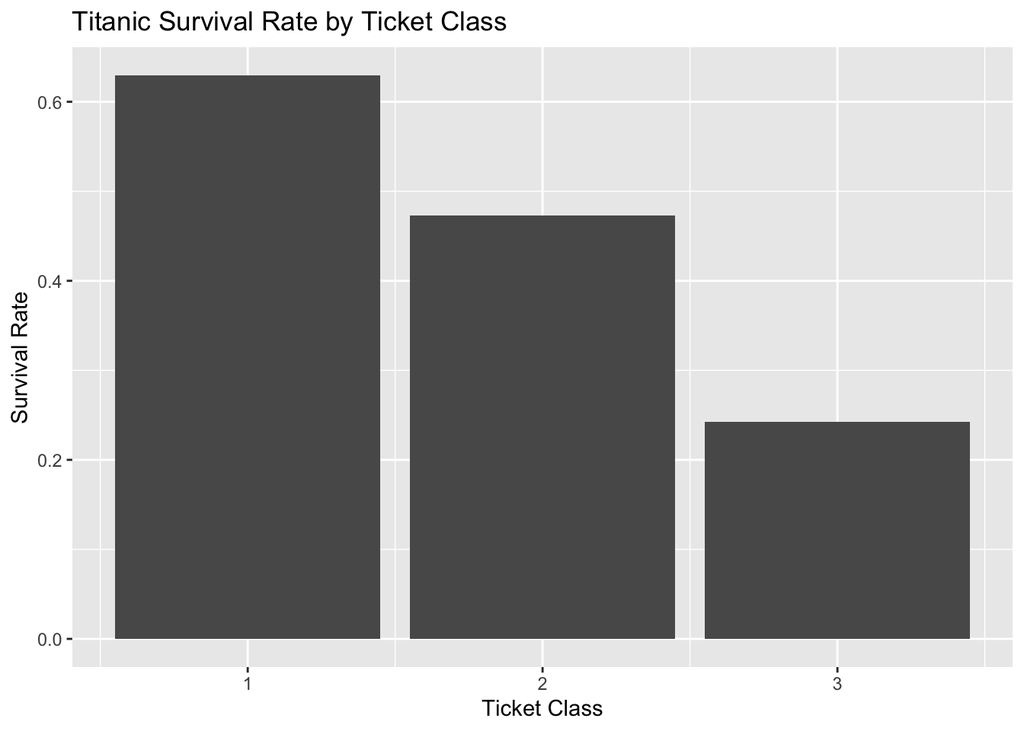

```r
train %>%
  group_by(Pclass) %>%
  summarize(Survived = sum(Survived),
            Total = n(),
            Proportion = Survived/Total) %>%
  ggplot() +
    geom_col(mapping = aes(x = Pclass, y = Proportion)) +
    labs(title = "Titanic Survival Rate by Ticket Class", x = "Ticket Class", y = "Survival Rate")
```

### Feature Engineering: Title

I created a new variable called “Title” to represent the passenger’s title extracted from their name.

There were a number of infrequently occuring titles, so I decided to fit them all into five categories: “Master”, “Mr”, “Mrs”, “Miss”, and “Royal” (for titles that indicated royalty). We can see that passengers with different titles have significantly different survival rates.

```r
### create Title from Name (train)
titles <- (str_extract(train$Name, pattern = "(?<=, ).+(?=\\. )"))
titles <- str_replace_all(titles, c("Jonkheer" = "Mr",
                                "Capt" = "Mr",
                                "Col" = "Mr",
                                "Don" = "Mr",
                                "Major" = "Mr",
                                "Rev" = "Mr",
                                "Sir" = "Royal",
                                "Dr" = "Mr",
                                "Lady" = "Royal",
                                "Mme" = "Mrs",
                                "Mrs. Martin \\(Elizabeth L" = "Mrs",
                                "the Countess" = "Royal",
                                "Mlle" = "Mrs",
                                "Ms" = "Miss"))
titles[797] <- "Mrs" # handle special case of female doctor
train$Title <- titles
table(train$Title) # Master, Miss, Mr, Mrs, Royal
```

```
##
## Master   Miss     Mr    Mrs  Royal
##     40    183    536    129      3
```

```r
### create Title from Name (test)
titles <- (str_extract(test$Name, pattern = "(?<=, ).+(?=\\. )"))
titles <- str_replace_all(titles, c("Col" = "Mr",
                                "Dona" = "Mrs",
                                "Dr" = "Mr",
                                "Ms" = "Miss",
                                "Rev" = "Mr"))
test$Title <- titles
table(test$Title) # Master, Miss, Mr, Mrs
```

```
##
## Master   Miss     Mr    Mrs
##     21     79    245     73
```

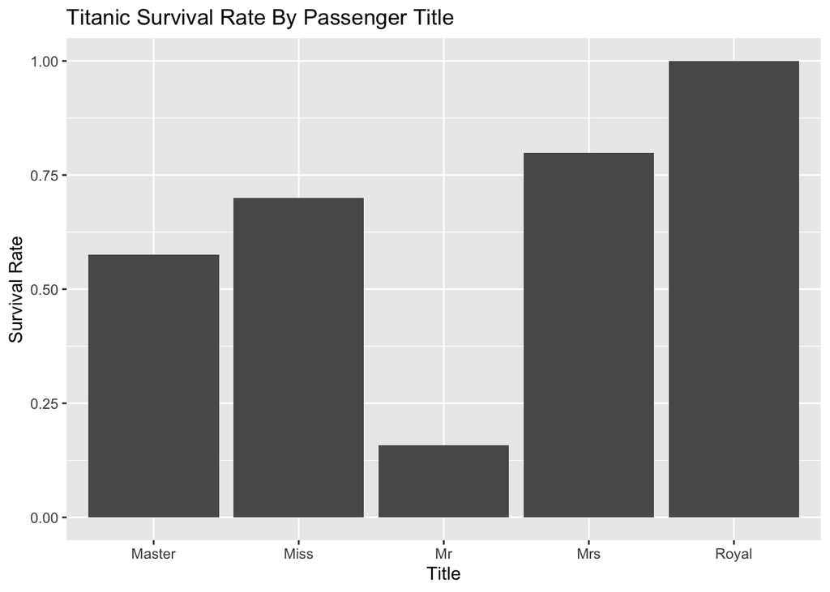

```r
rm(titles)

### graph survival rate by title
train %>%
  group_by(Title) %>%
  summarize(Survived = sum(Survived),
            Total = n(),
            Proportion = Survived/Total) %>%
  ggplot() +
    geom_col(mapping = aes(x = Title, y = Proportion)) +
    labs(title = "Titanic Survival Rate By Passenger Title", y = "Survival Rate")
```

### Feature Engineering: Family

I also created a new variable called “Family” from the sum of “SibSp” and “Parch” to represent the total number of the passenger’s family members aboard the Titanic. We can see that survival rates are significantly different among those with varying numbers of family members aboard.

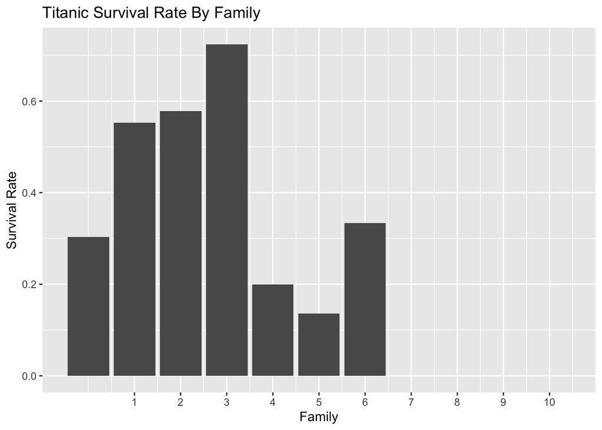

```r
### create Family from SibSp and Parch
train$Family <- train$SibSp + train$Parch
test$Family <- test$SibSp + test$Parch

### graph survival rate by family
train %>%
  group_by(Family) %>%
  summarize(Survived = sum(Survived),
            Total = n(),
            Proportion = Survived/Total) %>%
  ggplot() +
    geom_col(mapping = aes(x = Family, y = Proportion)) +
    labs(title = "Titanic Survival Rate By Family", y = "Survival Rate") +
    scale_x_continuous(breaks = seq(1, 10, by = 1))
```

### Missing Values: Overview

The training data is missing:

- 687 values of “Cabin”
- 177 values of “Age”
- 2 values of “Embarked”

The test data data is missing:

- 327 values of “Cabin”
- 86 values of “Age”
- 1 value of “Fare”

```r
summary(is.na(train))
```

```
##  PassengerId      Survived         Pclass           Name
##  Mode :logical   Mode :logical   Mode :logical   Mode :logical
##  FALSE:891       FALSE:891       FALSE:891       FALSE:891
##
##     Sex             Age            SibSp           Parch
##  Mode :logical   Mode :logical   Mode :logical   Mode :logical
##  FALSE:891       FALSE:714       FALSE:891       FALSE:891
##                  TRUE :177
##    Ticket           Fare           Cabin          Embarked
##  Mode :logical   Mode :logical   Mode :logical   Mode :logical
##  FALSE:891       FALSE:891       FALSE:204       FALSE:889
##                                  TRUE :687       TRUE :2
##    Title           Family
##  Mode :logical   Mode :logical
##  FALSE:891       FALSE:891
##
```

```r
summary(is.na(test))
```

```
##  PassengerId       Pclass           Name            Sex
##  Mode :logical   Mode :logical   Mode :logical   Mode :logical
##  FALSE:418       FALSE:418       FALSE:418       FALSE:418
##
##     Age            SibSp           Parch           Ticket
##  Mode :logical   Mode :logical   Mode :logical   Mode :logical
##  FALSE:332       FALSE:418       FALSE:418       FALSE:418
##  TRUE :86
##     Fare           Cabin          Embarked         Title
##  Mode :logical   Mode :logical   Mode :logical   Mode :logical
##  FALSE:417       FALSE:91        FALSE:418       FALSE:418
##  TRUE :1         TRUE :327
##    Family
##  Mode :logical
##  FALSE:418
##
```

### Missing Values: Cabin

[Accorording to Encyclopedia Titanica](https://www.encyclopedia-titanica.org/cabins.html), the letter prefix of the cabin represents the “Boat Deck” (A-G) while the number represents the room number.

**We’ll create a new variable called “Deck” to extract the deck information from the cabin variable.** Missing values of Cabin will be converted into a Deck value called “X”. We can see that those with missing cabin values have a noticeably different survival rate than the other groups.

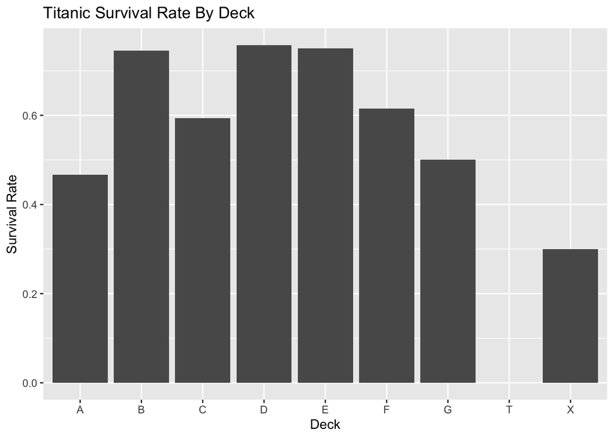

```r
### create Deck from Cabin
train$Deck <- ifelse(is.na(train$Cabin), "X", substr(train$Cabin, 0, 1))
test$Deck <- ifelse(is.na(test$Cabin), "X", substr(test$Cabin, 0, 1))

### graph survival rate by deck
train %>%
  group_by(Deck) %>%
  summarize(Survived = sum(Survived),
            Total = n(),
            Proportion = Survived/Total) %>%
  ggplot() +
    geom_col(mapping = aes(x = Deck, y = Proportion)) +
    labs(title = "Titanic Survival Rate By Deck", y = "Survival Rate")
```

### Missing Values: Age

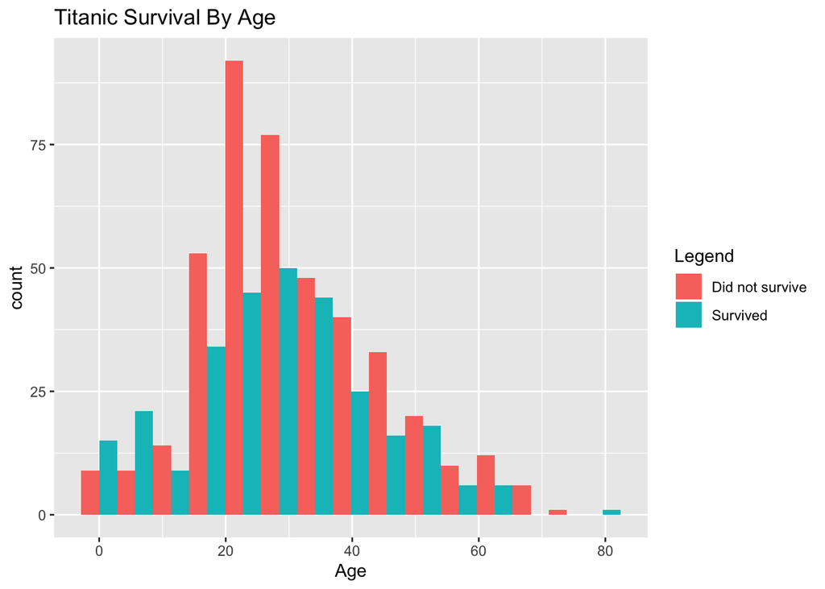

```r
### histogram of age, split by whether they survived
train %>%
  ggplot() +
    geom_histogram(mapping = aes(x = Age, fill = as.factor(Survived)),
                   bins = 15,
                   position = "dodge") +
    scale_fill_discrete(name = "Legend", labels = c("Did not survive", "Survived")) +
    labs(title = "Titanic Survival By Age")
```

I use linear regression-based imputation to fill in the missing values for “Age” based on the variables “Pclass”, “Title”, and “Family”, selected with forward stepwise selection.

The residuals of the predicted values of “Age” display heteroskedasticity in both the training and test data sets, but that’s acceptable for our purposes since we do not need an accurate measure of the model’s coefficient standard errors for prediction.

```r
### impute training data
lm1 <- lm(Age ~ Pclass + Title + Family, train)
summary(lm1)
```

```
##
## Call:
## lm(formula = Age ~ Pclass + Title + Family, data = train)
##
## Residuals:
##     Min      1Q  Median      3Q     Max
## -24.921  -8.545  -1.334   6.056  44.455
##
## Coefficients:
##             Estimate Std. Error t value Pr(>|t|)
## (Intercept)  23.8561     2.5623   9.310  < 2e-16 ***
## Pclass       -5.7955     0.5195 -11.155  < 2e-16 ***
## TitleMiss    11.9294     2.2605   5.277 1.75e-07 ***
## TitleMr      23.0749     2.2281  10.356  < 2e-16 ***
## TitleMrs     25.0628     2.2913  10.938  < 2e-16 ***
## TitleRoyal   26.0746     6.9288   3.763 0.000182 ***
## Family       -1.2029     0.3328  -3.614 0.000323 ***
## ---
## Signif. codes:  0 '***' 0.001 '**' 0.01 '*' 0.05 '.' 0.1 ' ' 1
##
## Residual standard error: 11.35 on 707 degrees of freedom
##   (177 observations deleted due to missingness)
## Multiple R-squared:  0.3948, Adjusted R-squared:  0.3897
## F-statistic: 76.88 on 6 and 707 DF,  p-value: < 2.2e-16
```

```r
plot(predict(lm1), resid(lm1), main = "Training Data: Residuals for Age Imputation") # heteroskedasticity
abline(0, 0)

train$Age <- ifelse(is.na(train$Age), predict(lm1, train), train$Age) # replace NAs with new values
train$Age[train$Age < 0] <- 1 # replace one negative predicted age with 1

# impute testing data
lm2 <- lm(Age ~ Pclass + Title + Family, test)
summary(lm2)
```

```
##
## Call:
## lm(formula = Age ~ Pclass + Title + Family, data = test)
##
## Residuals:
##     Min      1Q  Median      3Q     Max
## -25.493  -7.576  -0.597   6.669  33.747
##
## Coefficients:
##             Estimate Std. Error t value Pr(>|t|)
## (Intercept)  23.5439     3.6209   6.502 2.97e-10 ***
## Pclass       -6.6102     0.7284  -9.074  < 2e-16 ***
## TitleMiss    13.1164     3.1506   4.163 4.02e-05 ***
## TitleMr      23.0396     3.0537   7.545 4.56e-13 ***
## TitleMrs     26.1388     3.1651   8.258 3.74e-15 ***
## Family        0.4204     0.4818   0.873    0.383
## ---
## Signif. codes:  0 '***' 0.001 '**' 0.01 '*' 0.05 '.' 0.1 ' ' 1
##
## Residual standard error: 10.78 on 326 degrees of freedom
##   (86 observations deleted due to missingness)
## Multiple R-squared:  0.4312, Adjusted R-squared:  0.4225
## F-statistic: 49.43 on 5 and 326 DF,  p-value: < 2.2e-16
```

[figure not shown]

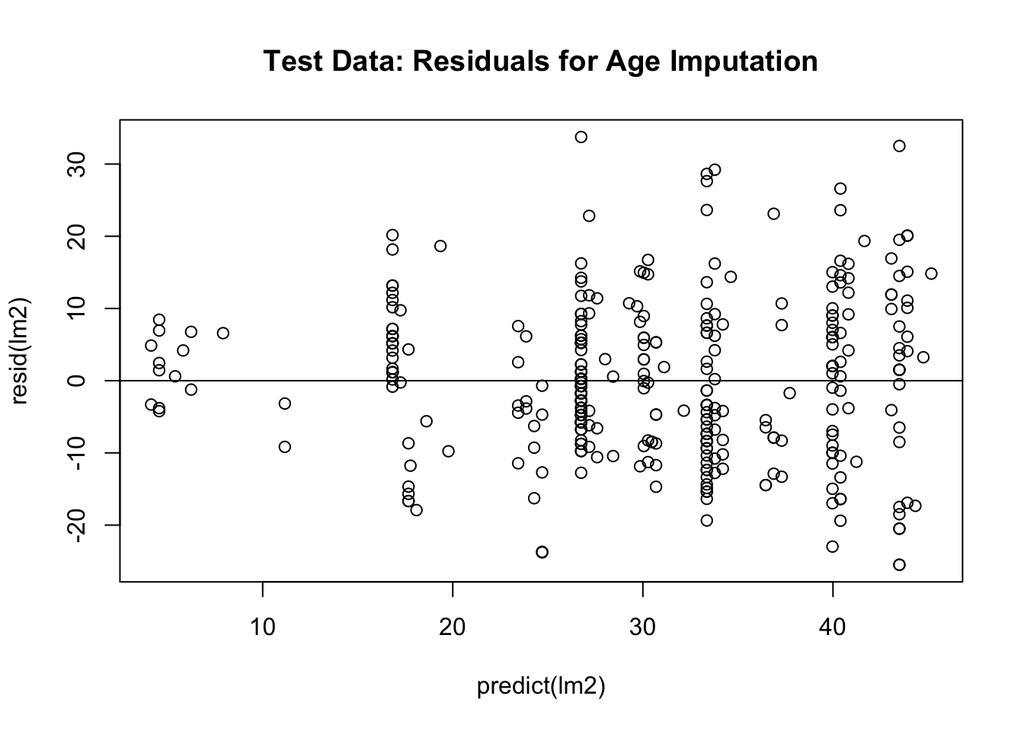

```r
plot(predict(lm2), resid(lm2), main = "Test Data: Residuals for Age Imputation") # heteroskedasticity
abline(0, 0)

test$Age <- ifelse(is.na(test$Age), predict(lm2, test), test$Age) # replace NAs with new values

rm(lm1, lm2)
```

### Missing Values: Embarked

The two missing values for “Embarked” in the training data set are for the two passengers: Miss Amelie Icard and Mrs. George Nelson Stone. I found that their port of embarkation is documented in public records; Miss Icard actually boarded the Titanic as maid to Mrs. Stone, and both boarded from Southampton.[^1]

```r
train %>% filter(is.na(Embarked))
```

```
## # A tibble: 2 x 15
##   PassengerId Survived Pclass Name  Sex     Age SibSp Parch Ticket  Fare Cabin
##         <dbl>    <dbl>  <dbl> <chr> <chr> <dbl> <dbl> <dbl> <chr>  <dbl> <chr>
## 1          62        1      1 Icar… fema…    38     0     0 113572    80 B28
## 2         830        1      1 Ston… fema…    62     0     0 113572    80 B28
## # … with 4 more variables: Embarked <chr>, Title <chr>, Family <dbl>,
## #   Deck <chr>
```

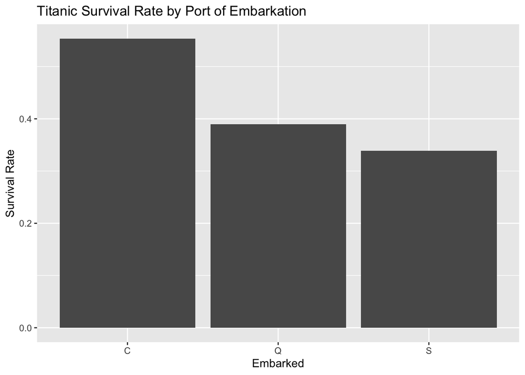

```r
train$Embarked <- ifelse(is.na(train$Embarked), "S", train$Embarked)

train %>%
  group_by(Embarked) %>%
  summarize(Survived = sum(Survived),
            Total = n(),
            Proportion = Survived/Total) %>%
  ggplot() +
    geom_col(mapping = aes(x = Embarked, y = Proportion)) +
    labs(title = "Titanic Survival Rate by Port of Embarkation", y = "Survival Rate")
```

### Missing Values: Fare

I filled in the one missing “Fare” in the test data set with the median fare in all the data.

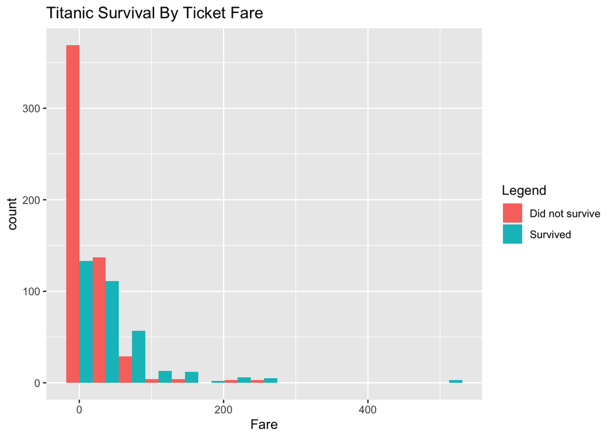

```r
full_data <- full_join(train, test)
test$Fare <- ifelse(is.na(test$Fare),
                    median(full_data$Fare, na.rm = TRUE),
                    test$Fare)
rm(full_data)

### histogram of fare, split by whether they survived
train %>%
  ggplot() +
    geom_histogram(mapping = aes(x = Fare, fill = as.factor(Survived)),
                   bins = 15,
                   position = "dodge") +
    scale_fill_discrete(name = "Legend", labels = c("Did not survive", "Survived")) +
    labs(title = "Titanic Survival By Ticket Fare")
```

### Additional Pre-Processing

I perform a few more steps for ease of computation in R and increased predictive power:

```r
### Encode categorical variables as factors
train$Survived <- factor(train$Survived)
train$Sex <- factor(train$Sex)
train$Title <- factor(train$Title)
train$Embarked <- factor(train$Embarked)
train$Deck <- factor(train$Deck)

test$Sex <- factor(test$Sex)
test$Title <- factor(test$Title)
test$Embarked <- factor(test$Embarked)
test$Deck <- factor(test$Deck)
levels(test$Deck) <- c(levels(test$Deck), "T")
levels(test$Title) <- c(levels(test$Title), "Royal")

### Encode training survival rate as a factor
train$Survived <- fct_recode(train$Survived, "Dead" = "0", "Survived" = "1")

### Create numeric Deck variable, Deck^2, and Fare^2
train$numericDeck <- as.numeric(train$Deck)
train$numericDeckSq <- train$numericDeck ^ 2
test$numericDeck <- as.numeric(test$Deck)
test$numericDeckSq <- test$numericDeck ^ 2

train$FareSq <- train$Fare ^ 2
test$FareSq <- test$Fare ^ 2
```

## Modeling

We will use 10-fold cross validation repeated 3 times to evaluate each model. The folds will be shared across models so that their predictions can be combined at the end.

```r
set.seed(202004071)
ctrl <- trainControl(method = "repeatedcv",
                     classProbs = TRUE,
                     number = 10,
                     repeats = 3,
                     index = createMultiFolds(train$Survived, k = 10, times = 3),
                     savePredictions = "final")
```

### Logistic Regression

Using logistic regression, we obtain an average cross-validated accuracy rate of 83.72%. We see that a title of “Mr”, the number of family members aboard the Titanic, ticket class, and age are the 4 most important contributors to survival in the logistic model.

```r
set.seed(20200407)
logitModel <- train(Survived ~ Pclass + Sex + Age + Fare + FareSq + Embarked + numericDeck + numericDeckSq + Title + Family, data = train,
                    method = "glm",
                    metric = "Accuracy",
                    trControl = ctrl)
logitModel # Acc: .8372
```

```
## Generalized Linear Model
##
## 891 samples
##  10 predictor
##   2 classes: 'Dead', 'Survived'
##
## No pre-processing
## Resampling: Cross-Validated (10 fold, repeated 3 times)
## Summary of sample sizes: 802, 802, 803, 802, 802, 802, ...
## Resampling results:
##
##   Accuracy   Kappa
##   0.8372159  0.6527131
```

```r
varImp(logitModel)
```

```
## glm variable importance
##
##                 Overall
## TitleMr       1.000e+02
## Family        8.582e+01
## Pclass        7.866e+01
## Age           5.477e+01
## numericDeckSq 3.373e+01
## numericDeck   2.898e+01
## EmbarkedS     2.711e+01
## FareSq        8.617e+00
## EmbarkedQ     8.043e+00
## Fare          2.837e-01
## TitleRoyal    2.329e-01
## TitleMrs      1.535e-02
## Sexmale       6.478e-03
## TitleMiss     0.000e+00
```

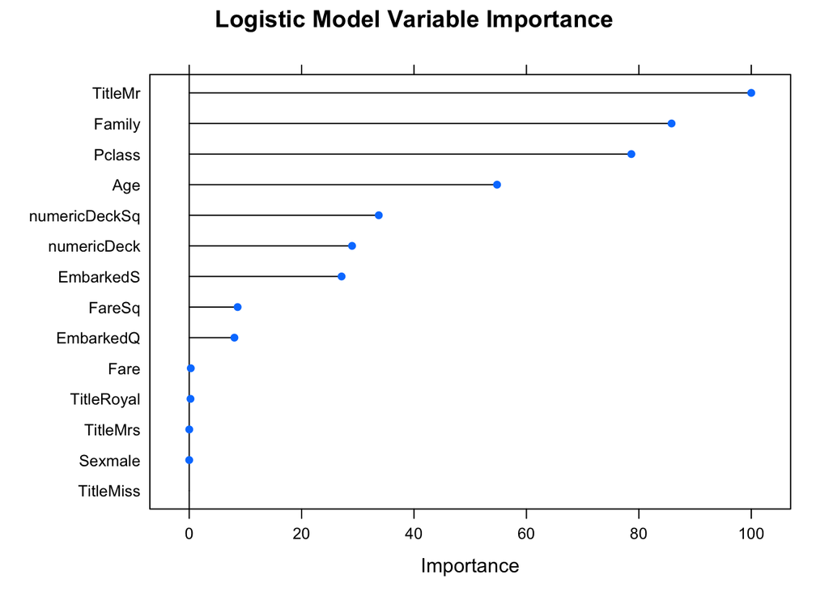

```r
plot(varImp(logitModel), main = "Logistic Model Variable Importance")
```

### Linear Discriminant Analysis

Using linear discriminant analysis, we obtain a cross-validated accuracy of 83.56%.

```r
set.seed(20200407)
ldaModel <- train(Survived ~ Pclass + Sex + Age + Fare + FareSq + Embarked + numericDeck + numericDeckSq + Title + Family,
                  data = train,
                  method = "lda",
                  metric = "Accuracy",
                  trControl = ctrl,
                  preProcess = c("center", "scale"))
ldaModel # Acc: .8356
```

```
## Linear Discriminant Analysis
##
## 891 samples
##  10 predictor
##   2 classes: 'Dead', 'Survived'
##
## Pre-processing: centered (14), scaled (14)
## Resampling: Cross-Validated (10 fold, repeated 3 times)
## Summary of sample sizes: 802, 802, 803, 802, 802, 802, ...
## Resampling results:
##
##   Accuracy  Kappa
##   0.835684  0.648136
```

### Linear SVM

A linear SVM gives a cross-validated accuracy of 83.61%.

```r
svmLGrid <- expand.grid(.C = 2^(-4:2))
set.seed(20200407)
svmLModel <- train(Survived ~ Pclass + Sex + Age + Fare + Embarked + numericDeck + numericDeckSq + Title + Family, data = train,
                    method = "svmLinear",
                    metric = "Accuracy",
                    preProc = c("center", "scale"),
                    tuneGrid = svmLGrid,
                    trControl = ctrl)
svmLModel # Acc = .8361
```

```
## Support Vector Machines with Linear Kernel
##
## 891 samples
##   9 predictor
##   2 classes: 'Dead', 'Survived'
##
## Pre-processing: centered (13), scaled (13)
## Resampling: Cross-Validated (10 fold, repeated 3 times)
## Summary of sample sizes: 802, 802, 803, 802, 802, 802, ...
## Resampling results across tuning parameters:
##
##   C       Accuracy   Kappa
##   0.0625  0.8312062  0.6368577
##   0.1250  0.8349558  0.6444466
##   0.2500  0.8353178  0.6451939
##   0.5000  0.8360668  0.6466546
##   1.0000  0.8356965  0.6459140
##   2.0000  0.8360668  0.6466631
##   4.0000  0.8360668  0.6466631
##
## Accuracy was used to select the optimal model using the largest value.
## The final value used for the model was C = 0.5.
```

### Polynomial SVM

A 2nd degree polynomial SVM gives a cross-validated accuracy of 83.91%.

```r
svmPGrid <- expand.grid(.C = 2^(-4:1),
                       .degree = 2,
                       .scale = .1)
set.seed(20200407)
svmPModel <- train(Survived ~ Pclass + Sex + Age + Fare + Embarked + numericDeck + numericDeckSq + Title + Family, data = train,
                    method = "svmPoly",
                    metric = "Accuracy",
                    preProc = c("center", "scale"),
                    tuneGrid = svmPGrid,
                    trControl = ctrl)
svmPModel # Acc = .8391
```

```
## Support Vector Machines with Polynomial Kernel
##
## 891 samples
##   9 predictor
##   2 classes: 'Dead', 'Survived'
##
## Pre-processing: centered (13), scaled (13)
## Resampling: Cross-Validated (10 fold, repeated 3 times)
## Summary of sample sizes: 802, 802, 803, 802, 802, 802, ...
## Resampling results across tuning parameters:
##
##   C       Accuracy   Kappa
##   0.0625  0.8304614  0.6348908
##   0.1250  0.8364371  0.6481069
##   0.2500  0.8390588  0.6528122
##   0.5000  0.8338154  0.6382964
##   1.0000  0.8327088  0.6324390
##   2.0000  0.8308362  0.6271753
##
## Tuning parameter 'degree' was held constant at a value of 2
## Tuning
##  parameter 'scale' was held constant at a value of 0.1
## Accuracy was used to select the optimal model using the largest value.
## The final values used for the model were degree = 2, scale = 0.1 and C = 0.25.
```

### Random Forest Model

A random forest model gives a cross-validated accuracy of 83.68%.

According to the random forest model, a title of “Mr” is the most significant variable for determining survival, followed by ticket class and fare.

```r
rfGrid <- expand.grid(.mtry = c(3, 5, 7, 9))
set.seed(20200407)
rfModel <- train(Survived ~ Pclass + Sex + Age + Fare + Embarked + numericDeck + Title + Family,
                 data = train,
                 method = "rf",
                 metric = "Accuracy",
                 trControl = ctrl,
                 importance = TRUE,
                 ntrees = 1000,
                 tuneGrid = rfGrid)
rfModel # Acc: .8368, mtry = 3
```

```
## Random Forest
##
## 891 samples
##   8 predictor
##   2 classes: 'Dead', 'Survived'
##
## No pre-processing
## Resampling: Cross-Validated (10 fold, repeated 3 times)
## Summary of sample sizes: 802, 802, 803, 802, 802, 802, ...
## Resampling results across tuning parameters:
##
##   mtry  Accuracy   Kappa
##   3     0.8368411  0.6442417
##   5     0.8345773  0.6413814
##   7     0.8271284  0.6278785
##   9     0.8200540  0.6147980
##
## Accuracy was used to select the optimal model using the largest value.
## The final value used for the model was mtry = 3.
```

```r
varImp(rfModel)
```

```
## rf variable importance
##
##             Importance
## TitleMr         100.00
## Pclass           72.68
## Fare             64.00
## Family           53.71
## Sexmale          51.66
## Age              50.94
## numericDeck      33.41
## EmbarkedS        26.75
## TitleMrs         20.59
## TitleMiss        19.98
## EmbarkedQ        15.33
## TitleRoyal        0.00
```

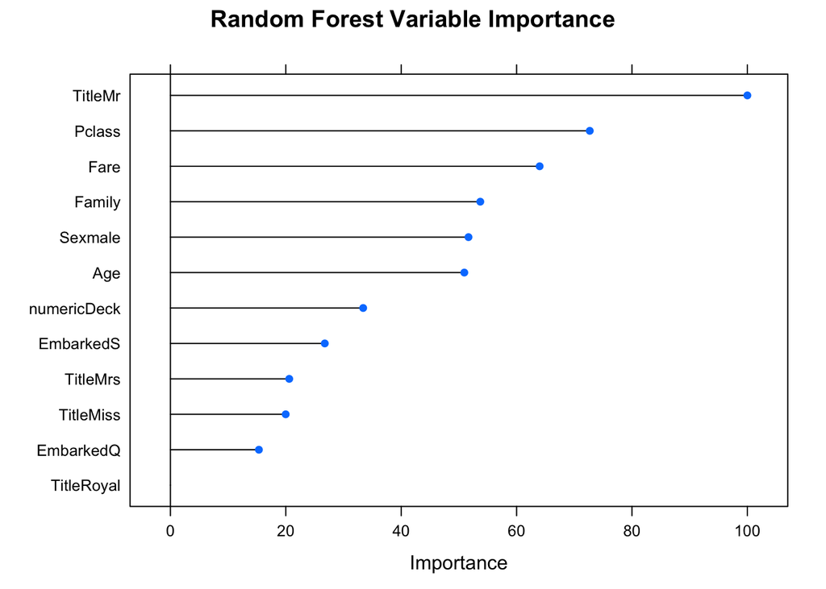

```r
plot(varImp(rfModel), main = "Random Forest Variable Importance")
```

### Ensemble

Since all of our models were trained on the same repeated 10-fold cross-validation samples, we’re able to easily calculate a good linear combination of their results.

The resulting average cross-validation accuracy of the ensemble 83.63%. Although this is lower than some of the individual model cross-validation scores, I expect it to be more robust.

```r
tuneList <- list(glm = caretModelSpec(method = "glm"))

set.seed(20200407)
modelList <<- caretList(Survived ~ Pclass + Sex + Age + Fare + FareSq + Embarked + numericDeck + numericDeckSq + Title + Family,
                        data = train,
                        trControl = ctrl,
                        metric = "Accuracy",
                        tuneList = tuneList)

modelList[["rf"]] <-  rfModel
modelList[["svmLinear"]] <- svmLModel
modelList[["svmPoly"]] <-  svmPModel
modelList[["lda"]] <- ldaModel

modelCor(resamples(modelList))
```

```
##                 glm        rf svmLinear   svmPoly       lda
## glm       1.0000000 0.8562156 0.8969526 0.8822264 0.8859745
## rf        0.8562156 1.0000000 0.8545746 0.8382657 0.8284880
## svmLinear 0.8969526 0.8545746 1.0000000 0.9585989 0.9378352
## svmPoly   0.8822264 0.8382657 0.9585989 1.0000000 0.9394595
## lda       0.8859745 0.8284880 0.9378352 0.9394595 1.0000000
```

```r
summary(resamples(modelList))
```

```
##
## Call:
## summary.resamples(object = resamples(modelList))
##
## Models: glm, rf, svmLinear, svmPoly, lda
## Number of resamples: 30
##
## Accuracy
##                Min.   1st Qu.    Median      Mean   3rd Qu.      Max. NA's
## glm       0.7528090 0.8089888 0.8426966 0.8372159 0.8651685 0.8988764    0
## rf        0.7640449 0.8117978 0.8426966 0.8368411 0.8662921 0.8876404    0
## svmLinear 0.7386364 0.8089888 0.8380150 0.8360668 0.8651685 0.8988764    0
## svmPoly   0.7500000 0.8089888 0.8426966 0.8390588 0.8735955 0.8988764    0
## lda       0.7500000 0.8112870 0.8380150 0.8356840 0.8647855 0.9000000    0
##
## Kappa
##                Min.   1st Qu.    Median      Mean   3rd Qu.      Max. NA's
## glm       0.4644420 0.5813084 0.6686948 0.6527131 0.7111952 0.7796424    0
## rf        0.4917052 0.5905426 0.6491007 0.6442417 0.7089625 0.7593294    0
## svmLinear 0.4269536 0.5849575 0.6588963 0.6466546 0.7103658 0.7846195    0
## svmPoly   0.4487472 0.5801198 0.6591454 0.6528122 0.7234431 0.7846195    0
## lda       0.4549550 0.5881626 0.6588963 0.6481360 0.7074114 0.7862797    0
```

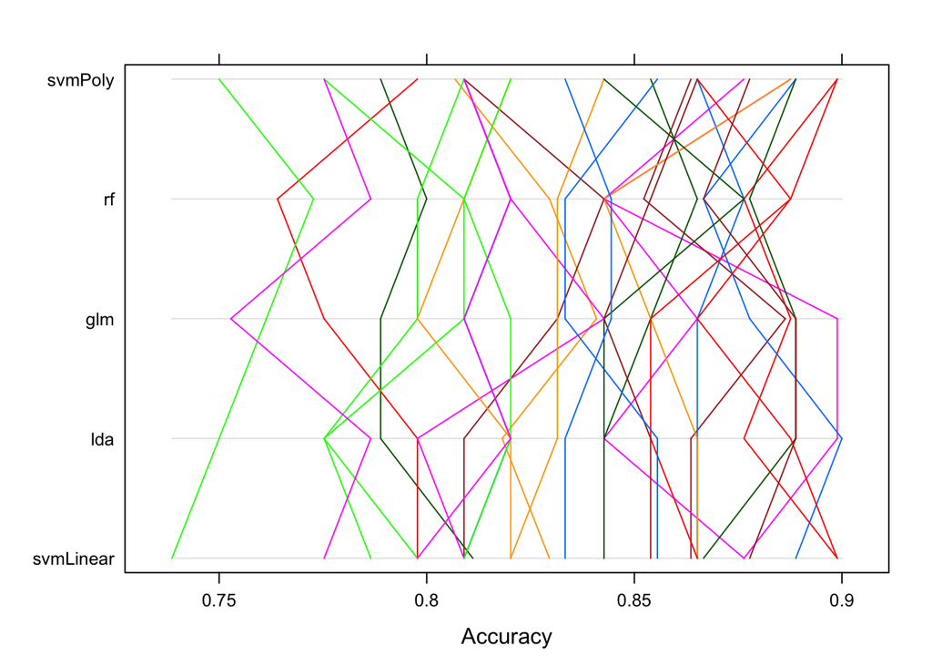

```r
parallelplot(resamples(modelList))
```

```r
set.seed(20200407)
greedyEnsemble <- caretEnsemble(modelList,
                                metric = "Accuracy",
                                trControl = trainControl(method = "repeatedcv", number = 10, repeats = 5))
summary(greedyEnsemble)
```

```
## The following models were ensembled: glm, rf, svmLinear, svmPoly, lda
## They were weighted:
## 2.9747 -5.849 -3.1424 0.9082 -1.4815 3.9094
## The resulting Accuracy is: 0.8363
## The fit for each individual model on the Accuracy is:
##     method  Accuracy AccuracySD
##        glm 0.8372159 0.03895557
##         rf 0.8368411 0.03369085
##  svmLinear 0.8360668 0.03932741
##    svmPoly 0.8390588 0.04131388
##        lda 0.8356840 0.03982689
```

## Results

This model had an accuracy of 79.90% on the test dataset, which is a fairly competitive score (top 12%).

For future improvement, I would investigate the effect of different imputation strategies and feature engineering.

```r
test$predictions <- predict(greedyEnsemble, test)
test$rawpredictions <- ifelse(test$predictions == "Dead", 0, 1)

submission <- tibble("PassengerId" = test$PassengerId,
                     "Survived" = test$rawpredictions)

write.csv(submission, "titanic-submission.csv", row.names = FALSE, quote = FALSE)
```